# Supervised learning competition

Authors

Ezra Gerris

Julia van Heeringen

Ana Melchor Pérez

Published

October 21, 2023

# Data description & visualization

Based on the data provided by the function summary(), we divided the insights into 3 aspects: education, demographics / lifestyle and family situation.

```r
#No null values
sum(is.na(train))
```

```
[1] 0
```

```r
#Confirmed that there are no null values
sapply(train, function(x) sum(is.na(x)))
```

```
    school        sex        age    address    famsize    Pstatus       Medu
         0          0          0          0          0          0          0
      Fedu       Mjob       Fjob     reason   guardian traveltime  studytime
         0          0          0          0          0          0          0
  failures  schoolsup     famsup       paid activities    nursery     higher
         0          0          0          0          0          0          0
  internet   romantic     famrel   freetime      goout       Dalc       Walc
         0          0          0          0          0          0          0
    health   absences      score
         0          0          0
```

```r
#Only factor and numeric data types so nothing needs to be changed here
sapply(train, function(x) class(x))
```

```
    school        sex        age    address    famsize    Pstatus       Medu
  "factor"   "factor"  "numeric"   "factor"   "factor"   "factor"  "numeric"
      Fedu       Mjob       Fjob     reason   guardian traveltime  studytime
 "numeric"   "factor"   "factor"   "factor"   "factor"  "numeric"  "numeric"
  failures  schoolsup     famsup       paid activities    nursery     higher
 "numeric"   "factor"   "factor"   "factor"   "factor"   "factor"   "factor"
  internet   romantic     famrel   freetime      goout       Dalc       Walc
  "factor"   "factor"  "numeric"  "numeric"  "numeric"  "numeric"  "numeric"
    health   absences      score
 "numeric"  "numeric"  "numeric"
```

```r
#It seems that all columns have several different values that can be associated with it
sapply(train, function(x) length(unique(x)))
```

```
    school        sex        age    address    famsize    Pstatus       Medu
         2          2          8          2          2          2          5
      Fedu       Mjob       Fjob     reason   guardian traveltime  studytime
         5          5          5          4          3          4          4
  failures  schoolsup     famsup       paid activities    nursery     higher
         4          2          2          2          2          2          2
  internet   romantic     famrel   freetime      goout       Dalc       Walc
         2          2          5          5          5          5          5
    health   absences      score
         5         31        169
```

## Education

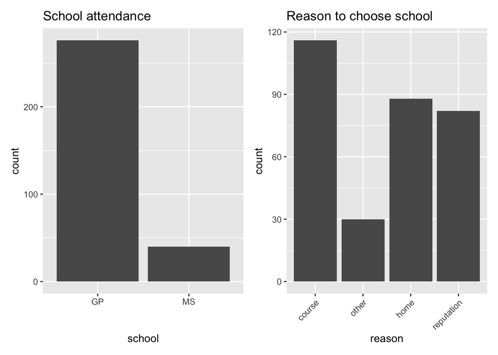

```r
#Bar plot for school attendance
edu1 <- ggplot(train, aes(x = school)) + geom_bar() + labs( title = "School attendance")

#Bar plot for reason to choose the school
edu2 <- ggplot(train, aes(x = reason)) + geom_bar() + labs(title = "Reason to choose school") + theme(axis.text.x = element_text(angle = 45, hjust = 1))

#Bar plot for past class failures
edu3 <- ggplot(train, aes(x = failures)) + geom_bar() + labs(title = "Past class failures")

#Histogram for weekly study time
edu4 <- ggplot(train, aes(x = factor(studytime))) +
  geom_bar(width = 0.5, fill = "orange") +
  labs(title = "Weekly study time", x = "Study Time") +
  scale_x_discrete(labels = c("<2 hours", "2 to 5 hours", "5 to 10 hours", ">10 hours"))

#Bar plot for extra educational support
edu5 <- ggplot(train, aes(x = schoolsup)) + geom_bar() + labs(title = "Extra educational support")

#Histogram for school absences
edu6 <- ggplot(train, aes(x = absences)) + geom_histogram(binwidth = 3, fill = "blue") + labs(title = "School absences")

#Histogram for travel time
edu7 <- ggplot(train, aes(x = traveltime)) + geom_histogram(binwidth = 0.5, fill = "purple") + labs(title = "Travel time to school")

#Density plot for the final grades (score)
edu8 <- ggplot(train, aes(x = score)) + geom_density(fill = "orange", alpha = 0.5) + labs(title = "Final grades")

edu1 + edu2
```

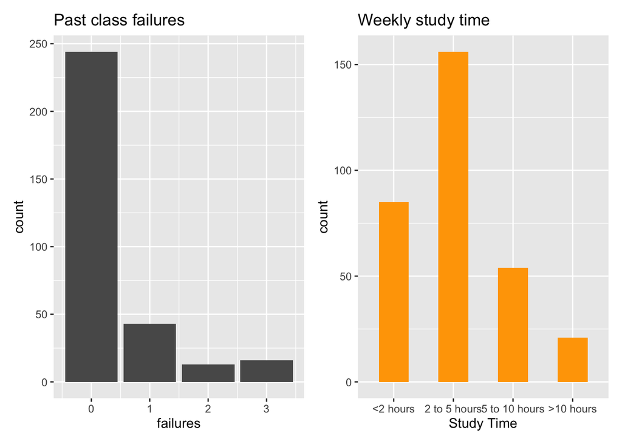

```r
edu3 + edu4
```

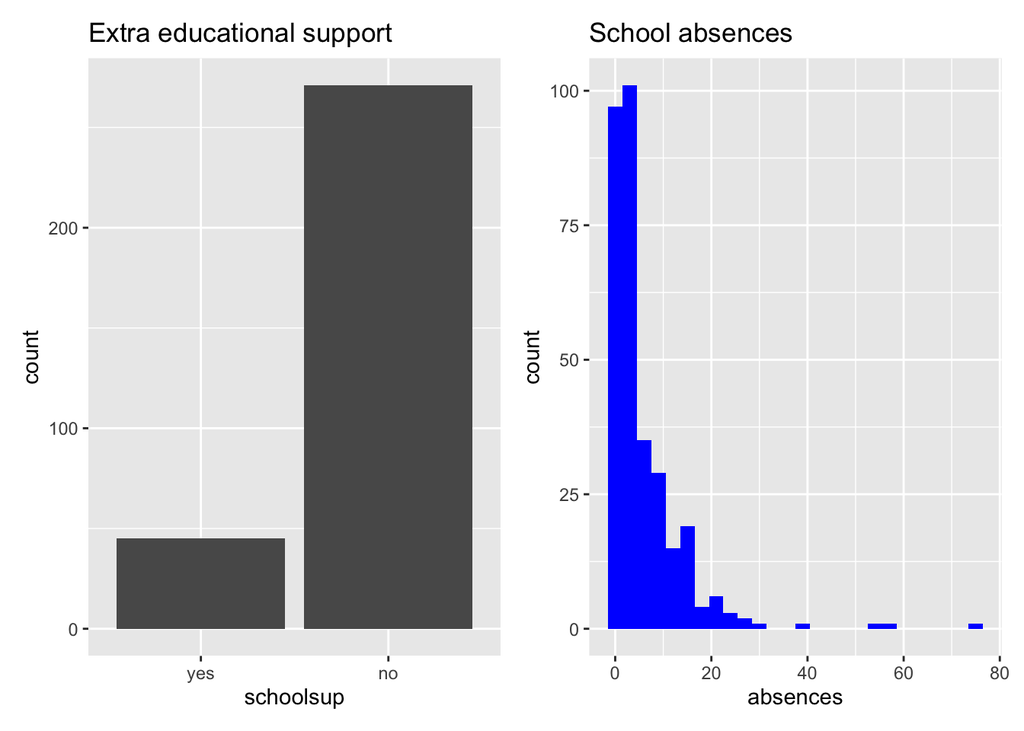

```r
edu5 + edu6
```

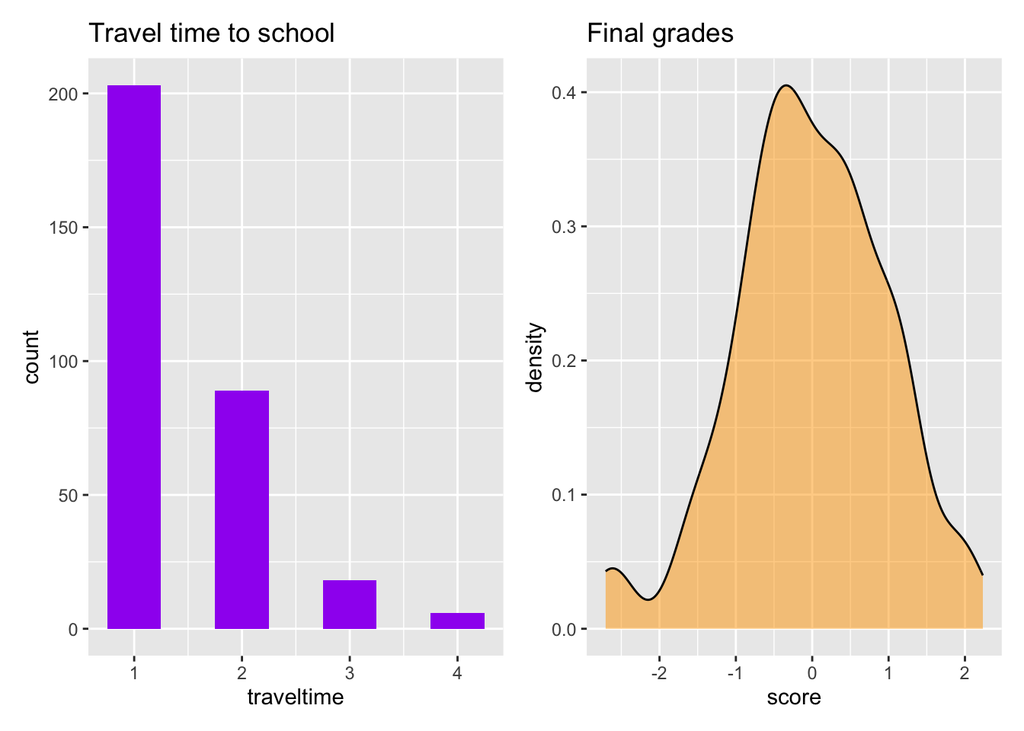

```r
edu7 + edu8
```

## Demographics / Lifestyle

The students’ ages range from 15 to 22, with an average age of approximately 16.75 years. Among them, 173 are female, and 143 are male. The majority of students (246) live in urban areas (address “U”), compared to about 70 students who come from rural areas (address “R”). Students have moderate free time, social activity, and alcohol consumption. A majority aspire to higher education (298), have internet access at home (257), and are not in romantic relationships (213). Family educational support (famsup) is provided to 193 students. Extracurricular activities (activities) are common among 162 students.

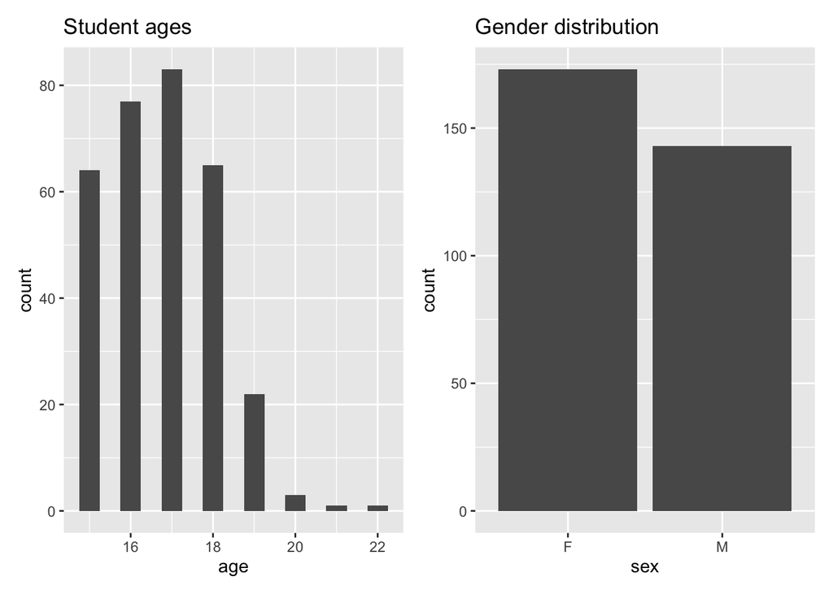

```r
#Histogram for student ages
dem1 <- ggplot(train, aes(x = age)) + geom_histogram(binwidth = 0.5) + labs(title = "Student ages")

#Bar plot for gender distribution
dem2 <- ggplot(train, aes(x = sex)) + geom_bar() + labs(title = "Gender distribution")

#Bar plot for student address
dem3 <- ggplot(train, aes(x = address)) + geom_bar() + labs(title = "Student address")

#Bar plot for student free time
dem4 <- ggplot(train, aes(x = freetime)) + geom_bar() + labs(title = "Free time after school")

#Bar plot for student social activity (goout)
dem5 <- ggplot(train, aes(x = goout)) + geom_bar() + labs(title = "Social activity (Go out with friends)")

#Stacked bar plot for alcohol use
dem6 <-
  train %>%
    pivot_longer(cols = c(Dalc, Walc), names_to = "Day", values_to = "Consumption") %>%
    ggplot(aes(x = Day, fill = factor(Consumption))) +
    geom_bar(position = "stack") +
    theme_minimal() +
    labs(x = "Day Type", fill = "Consumption level") +
    scale_x_discrete(labels = c(Dalc = "Workday", Walc = "Weekend"))

#Bar plot for student aspiration for higher education
dem7 <- ggplot(train, aes(x = higher)) + geom_bar() + labs(title = "Aspiration for higher education", x = "Higher education")

#Bar plot for internet access at home
dem8 <- ggplot(train, aes(x = internet)) + geom_bar() + labs(title = "Internet access at home", x = "Internet Access")

#Bar plot for romantic relationships
dem9 <- ggplot(train, aes(x = romantic)) + geom_bar() + labs(title = "Romantic Relationships", x = "Romantic Relationship")

#Bar plot for family educational support (famsup)
dem10 <- ggplot(train, aes(x = famsup)) + geom_bar() + labs(title = "Family educational support", x = "Support")

#Bar plot for extracurricular activities (activities)
dem11 <- ggplot(train, aes(x = activities)) + geom_bar() + labs(title = "Extracurricular Activities")

dem1 + dem2
```

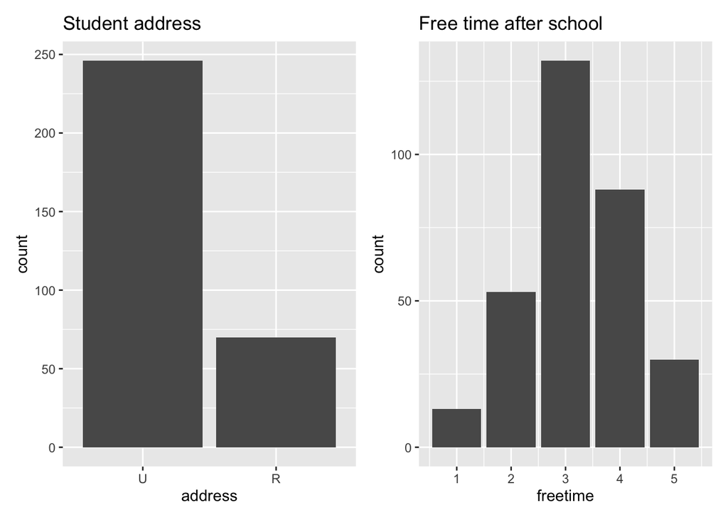

```r
dem3 + dem4
```

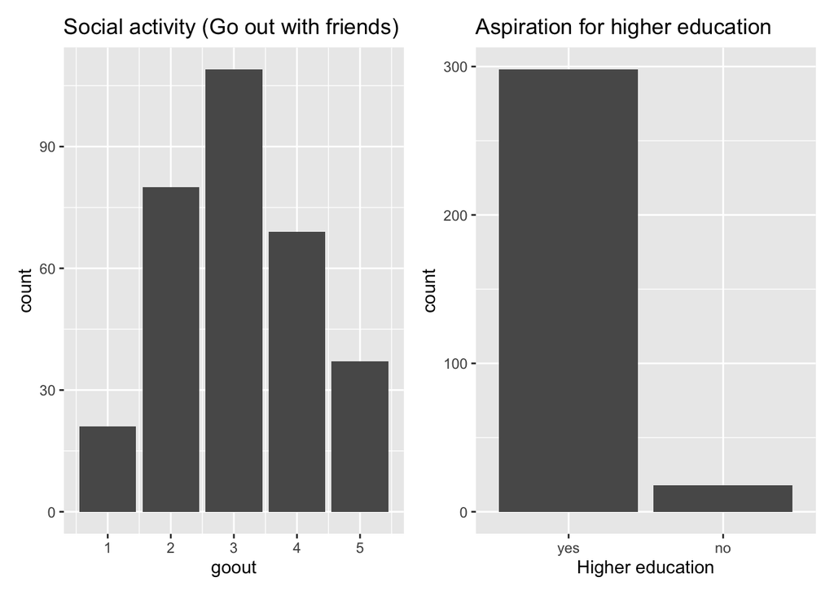

```r
dem5 + dem7
```

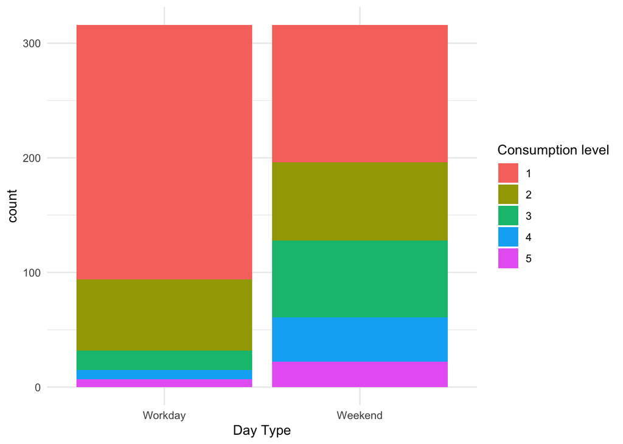

```r
dem6
```

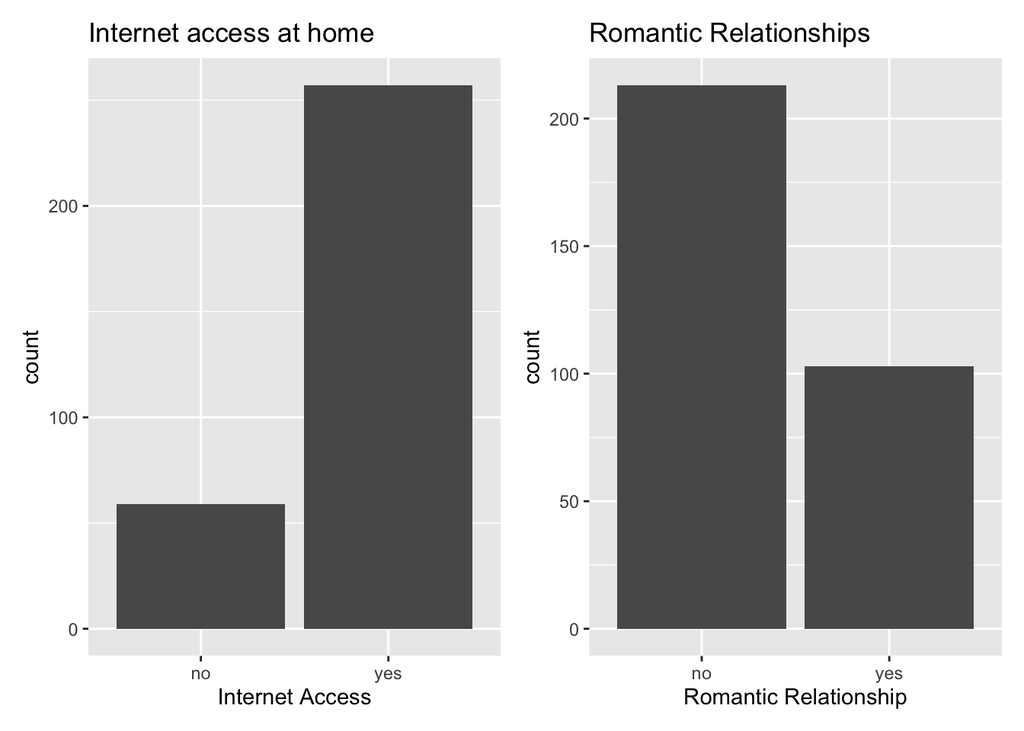

```r
dem8 + dem9
```

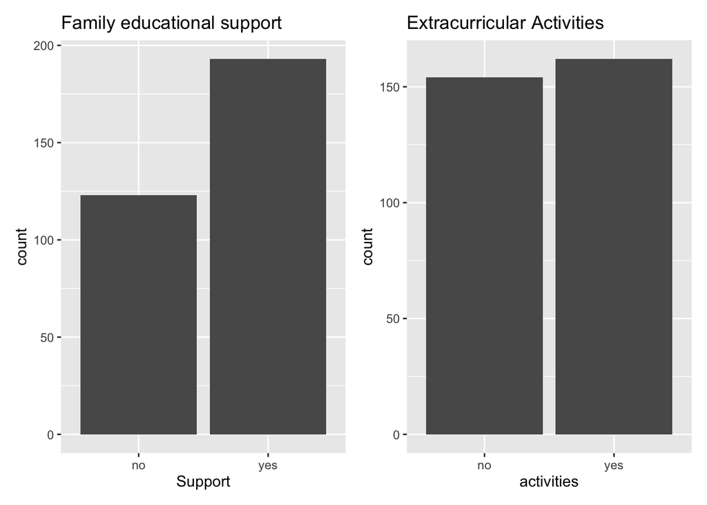

```r
dem10 + dem11
```

## Family situation

Regarding family size, 224 students have families with more than 3 members (GT3), while 92 come from families with 3 or fewer members (LE3). Most parents (282) are living together (Pstatus “T”). Family relationships (famrel) are generally rated positively (mean around 3.93). Parental education levels (Medu and Fedu) mostly fall within the range of secondary education, with mean values around 2.7. “Other” is the most common mother’s (116) and father’s (176) job. Teachers and service-related jobs also appear frequently. Mothers are the most common guardians (214). The average travel time to school is approximately 1.45, and students spend around 2 hours studying per week.

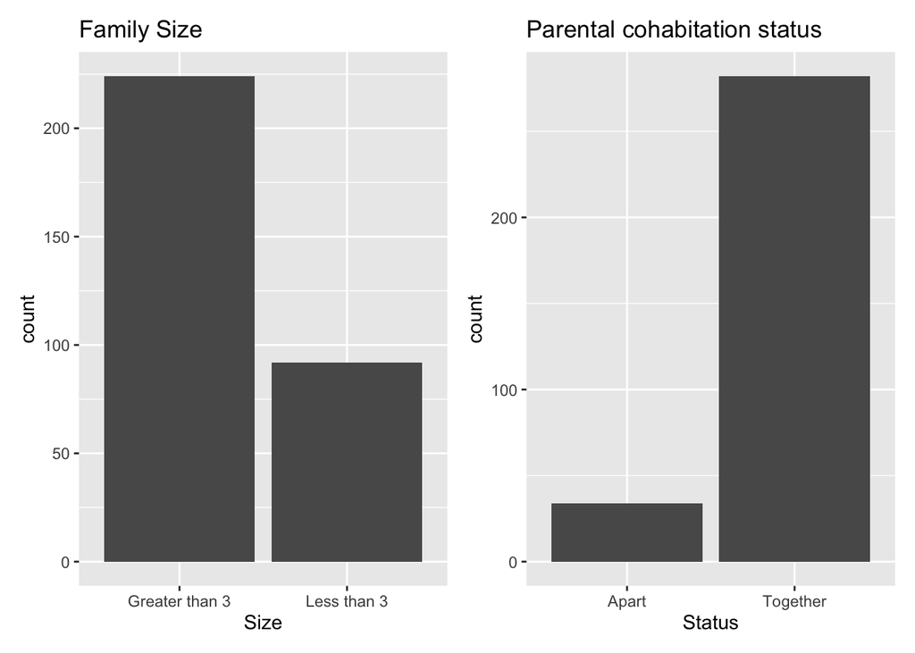

```r
#Bar plot for family size
fam1 <- ggplot(train, aes(x = famsize)) + geom_bar() + labs(title = "Family Size", x = "Size") + scale_x_discrete(labels = c("Greater than 3", "Less than 3"))

#Bar plot for parental cohabitation status
fam2 <- ggplot(train, aes(x = Pstatus)) + geom_bar() + labs(title = "Parental cohabitation status", x = "Status") + scale_x_discrete(labels = c("Apart", "Together"))

#Histogram for family relationships
fam3 <- ggplot(train, aes(x = famrel)) + geom_histogram(binwidth = 0.5, fill = "red") + labs(title = "Quality of family relationships", x = "Level")

#Bar plot for guardian
fam4 <- ggplot(train, aes(x = guardian)) + geom_bar() + labs(title = "Student's guardian")

#Bar plot for parents' education
fam5 <-
  train %>%
    pivot_longer(cols = c(Fedu, Medu), names_to = "Parent", values_to = "Education") %>%
      ggplot(aes(x = factor(Education), fill = Parent)) +
      geom_bar(position = "dodge") +
      theme_minimal() +
      labs(title = "Parents' education", x = "Education level", fill = "Parent") +
      scale_fill_manual(labels = c("Father", "Mother"), values = c("blue", "pink"))

#Bar plot for parents' job
fam6 <-
  train %>%
    pivot_longer(cols = c(Fjob, Mjob), names_to = "Parent", values_to = "Job") %>%
      ggplot(aes(x = factor(Job), fill = Parent)) +
      geom_bar(position = "dodge") +
      theme_minimal() +
      labs(title = "Parents' job", x = "Job type", fill = "Parent") +
      scale_fill_manual(labels = c("Father", "Mother"), values = c("blue", "pink")) +
      theme(axis.text.x = element_text(angle = 45, hjust = 1))


fam1 + fam2
```

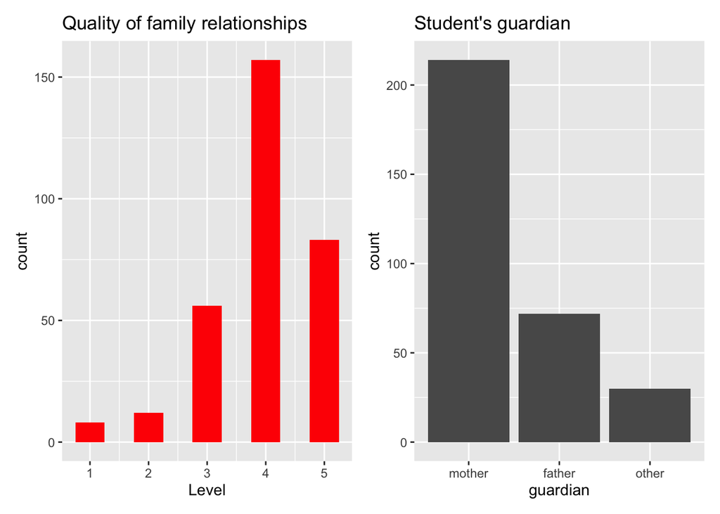

```r
fam3 + fam4
```

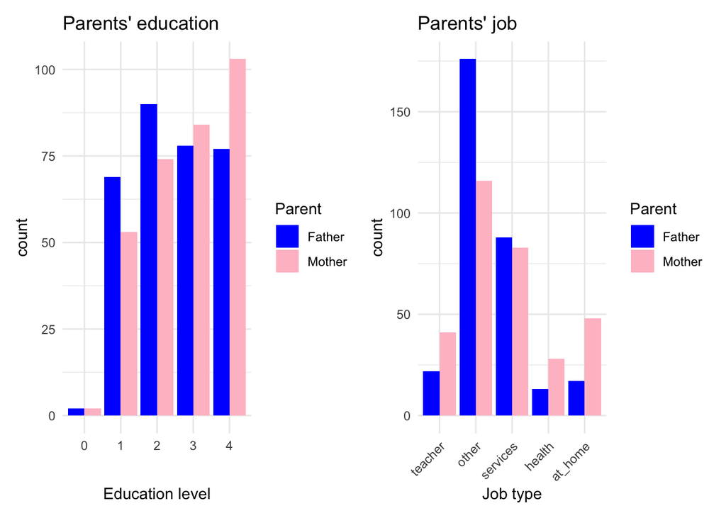

```r
fam5 + fam6
```

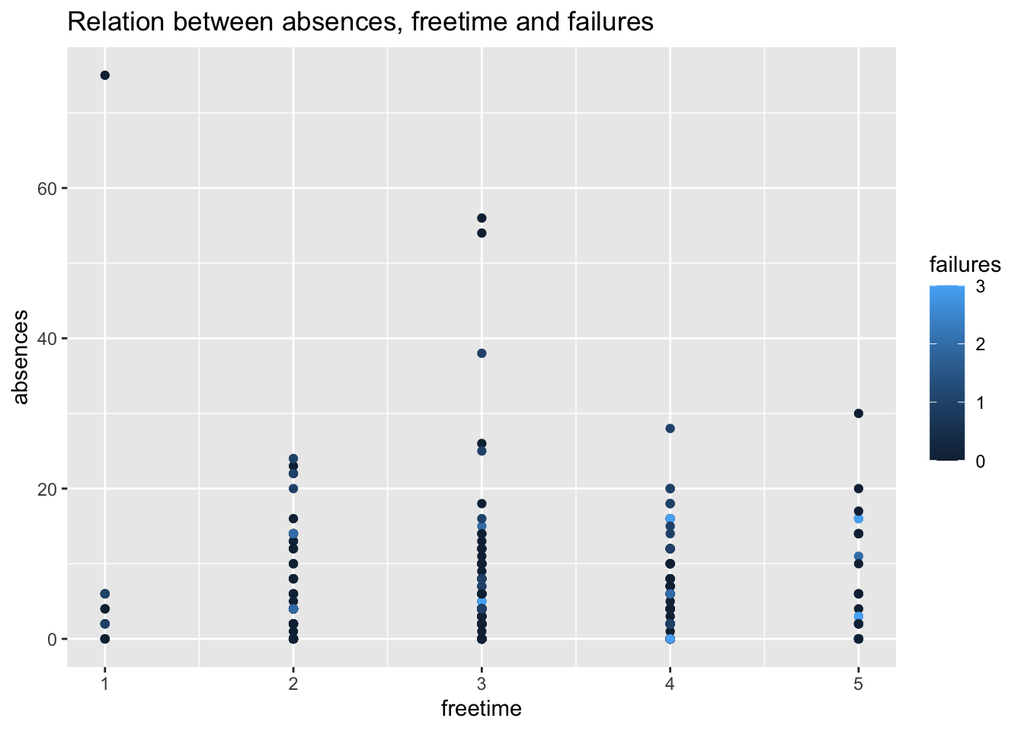

```r
#Bar plot for estimating relation between absences, freetime and failures
fam7 <- ggplot(train, aes(x = freetime, y = absences, color = failures)) + geom_point() +
      labs(title = "Relation between absences, freetime and failures")
fam7
```

Regarding outliers, there could be one outlier in above graph. Namely, a person who has very low freetime, very high absence, but never fails a class. Let’s look at the details.

```r
train$absences <- as.numeric(as.character(train$absences))
selected_rows <- train[train$absences > 60, ]
selected_rows
```

| school | sex | age | address | famsize | Pstatus | Medu | Fedu | Mjob | Fjob | reason | guardian | traveltime | studytime | failures | schoolsup | famsup | paid | activities | nursery | higher | internet | romantic | famrel | freetime | goout | Dalc | Walc | health | absences | … |
| --- | --- | --- | --- | --- | --- | --- | --- | --- | --- | --- | --- | --- | --- | --- | --- | --- | --- | --- | --- | --- | --- | --- | --- | --- | --- | --- | --- | --- | --- | --- |
| GP | F | 18 | R | GT3 | A | 3 | 2 | other | services | home | mother | 2 | 2 | 0 | no | no | no | no | no | no | yes | yes | 4 | 1 | 1 | 1 | 1 | 5 | 75 | … |

Since this is the only potential outlier, we will not do anything regarding the different strategies of handling outliers.

# Model description

## Linear Regression

The first model we will use to predict the students’ score is multiple linear regression. In order to find the best predictor variables for the model, we can use an automated selection approach that will give us the most efficient variables. We could also input the different predictor variables manually, but this would suggest trying a lot of different combinations. The three selection techniques are forward, backward and mixed selection. There is not one perfect technique, because it depends on the dataset. In the book Introduction to Statistical Learning from James et al., we find reasoning for each of them. In order to find the best fitting model, the selection techniques use Akaike Information Criterion (AIC). We find that with backward and mixed selection, there are 11 predictor variables that fit the best, namely:

score ~ sex + age + Medu + Mjob + studytime + failures + schoolsup + famsup + romantic + goout + health

Using forward selection, we find that the best model includes all variables (30 in total). It would not be a good choice to make a model with so many predictor variables, since this has more potential to lead to overfitting. We will still take the full model in account by comparing both regarding mean squared error (MSE).

```r
#First let's use forward, backward and stepwise regression to see what predictor variables would be good to use in our model. We will try with 'forward', 'backward' and 'both.'

full.model <- lm(score ~., data = train)
step.model <- stepAIC(full.model, direction = "backward", trace = FALSE)
summary(step.model)
```

```
Call:
lm(formula = score ~ sex + age + Medu + Mjob + studytime + failures +
    schoolsup + famsup + romantic + goout + health, data = train)

Residuals:
    Min      1Q  Median      3Q     Max
-2.8638 -0.5442  0.0217  0.5701  2.1940

Coefficients:
             Estimate Std. Error t value Pr(>|t|)
(Intercept)   1.01177    0.72557   1.394  0.16421
sexM          0.32856    0.10546   3.115  0.00201 **
age          -0.06407    0.04119  -1.556  0.12083
Medu          0.11988    0.05946   2.016  0.04467 *
Mjobhealth    0.23321    0.23602   0.988  0.32391
Mjobother    -0.20993    0.15305  -1.372  0.17121
Mjobservices  0.05116    0.16989   0.301  0.76354
Mjobteacher  -0.22543    0.22568  -0.999  0.31865
studytime     0.11298    0.06150   1.837  0.06718 .
failures     -0.40021    0.06715  -5.960 7.06e-09 ***
schoolsupno   0.41567    0.14550   2.857  0.00458 **
famsupyes    -0.16495    0.10390  -1.588  0.11341
romanticyes  -0.18472    0.10444  -1.769  0.07795 .
goout        -0.13973    0.04521  -3.091  0.00218 **
health       -0.06000    0.03560  -1.685  0.09297 .
---
Signif. codes:  0 '***' 0.001 '**' 0.01 '*' 0.05 '.' 0.1 ' ' 1

Residual standard error: 0.8475 on 301 degrees of freedom
Multiple R-squared:  0.2943,    Adjusted R-squared:  0.2615
F-statistic: 8.967 on 14 and 301 DF,  p-value: < 2.2e-16
```

Regarding the computation of the MSE, we use a 10-fold cross validation to iterate over the model and eventually find the average MSE that has been found from this process.

```r
mse_values <- c()
for(i in 1:10){
  sample_idx <- sample(c(TRUE, FALSE), nrow(train), replace=TRUE, prob=c(0.9,0.1))
  train_split <- train[sample_idx, ]
  test_split <- train[!sample_idx, ]
  lm_model <- lm(score ~ sex + age + Medu + Mjob + studytime + failures + schoolsup + famsup + romantic + goout + health, data = train_split)
  #lm_model <- lm(score ~ ., data = train_split)
    #Try running this to see that the MSE of the full model is higher
  y_true <- test_split$score
  y_pred <- predict(lm_model, newdata=test_split)
  mse_val <- mean((y_true - y_pred)^2)
  mse_values <- c(mse_values, mse_val)
}
lm_cv_mse <- sum(mse_values)/10
lm_cv_mse
```

```
[1] 0.7382298
```

```r
#We make a dataframe to store the cross validated MSE values for each of our 3 models
mse_df <- data.frame(model_name = "Linear Model", mse = lm_cv_mse)
```

## K-Nearest Neighbors

For the next method, we focused on comparing different variations of k-nearest neighbors (KNN) regression models for predicting student performance. Specifically, we systematically tested a range of “k” values, representing the number of nearest neighbors used for predictions. The core comparison revolved around evaluating how the choice of “k” impacts model performance.

To do this, we initialized a set of k-values from 2 to 10 and iterated through them, training a KNN regression model for each “k” and using 10 fold cross validation to evaluate their performance on each of these 10 folds. Thus, the MSE for each k-value is the average of the 10 MSE values on each of the folds obtained through cross validation. The model’s accuracy was directly linked to the choice of “k,” making it a critical hyperparameter to optimize.

```r
#Convert the target variable to numeric
train_y <- as.numeric(train[["score"]])

#Scale the numeric columns for predictor variables
numeric_train_columns <- train[, sapply(train, is.numeric)]
train_x <- scale(numeric_train_columns)
```

```r
mod_knn = train(x = train_x,y = train_y, method = "knn", tuneGrid = data.frame(k = c(2:10)), trControl = trainControl(method = "repeatedcv",number = 10,repeats = 3))
mod_knn
```

```
k-Nearest Neighbors

316 samples
 14 predictor

No pre-processing
Resampling: Cross-Validated (10 fold, repeated 3 times)
Summary of sample sizes: 284, 284, 285, 284, 285, 285, ...
Resampling results across tuning parameters:

  k   RMSE       Rsquared   MAE
   2  0.6280910  0.5937179  0.5036965
   3  0.5997633  0.6395475  0.4745392
   4  0.5830985  0.6708359  0.4625689
   5  0.5777221  0.6926340  0.4566119
   6  0.5740790  0.7093735  0.4498196
   7  0.5635631  0.7337977  0.4415829
   8  0.5591489  0.7504099  0.4355782
   9  0.5615706  0.7607428  0.4331792
  10  0.5646177  0.7645324  0.4356804

RMSE was used to select the optimal model using the smallest value.
The final value used for the model was k = 8.
```

```r
#k=8 resulted in the lowest cross validated RMSE
```

By systematically assessing these different k-values, we aimed to determine the best “k” that minimizes prediction errors and yields the most accurate model. This comparison process gives k = 8 as the lowest cross validated error. However, the model uses RMSE instead of MSE so the final value should be converted in order to be able to compare MSE’s afterwards.

```r
#RMSE value for k=8, needs to be converted to MSE to be able to compare to other model performance
rmse_knn <- mod_knn$results$RMSE[7]
knn_cv_mse <- rmse_knn^2

#Add the mse to the final dataframe
mse_df <- rbind(mse_df, data.frame(model_name = "knn", mse = knn_cv_mse))
```

## Random Forest

Finally, the random forest model was selected for its high predictive accuracy, ability to work with categorical and numeric variables, and its feature importance metric. Random forests work by building many decision trees, each only utilizing a subset of predictors, and combining their results to make a prediction. This data set has 30 predictive features, which is too many to work with because this could lead to overfitting as the model becomes extremely sensitive to the training data. Luckily, due to the nature of random forests, they already attempt to minimize overfitting by decorrelating trees and only using a select number of features at a time. While feature reduction is not completely necessary, removing seemingly insignificant features will further minimize the risk of overfitting.

To begin the model fitting process, we fit a random forest model with all of the predictors and eliminated the ones with the lowest feature importances listed in the model summary. The variables that were dropped from the subsequent models were school, address, family size, parent’s cohabitation status, whether they attended nursery school, whether they took extra paid classes, whether they wanted to pursue higher education, whether they had internet access at home, whether they participated in extracurricular activities, if they had a romantic relationship, and their workday alcohol consumption.

```r
#Note: takes a couple of seconds to run
rf <- randomForest(score~., data=train)
rf_cv <- rf.crossValidation(rf, xdata=train[, names(train)!="score"], ydata=train$score, p=0.10, n=10)
```

```
running: regression cross-validation with 10 iterations
```

```r
rf_cv$fit.mse
```

```
[1] 0.768293
```

```r
#Looking at feature importances (drop lowest)
importances <- importance(rf)
importances
```

```
           IncNodePurity
school          2.368901
sex             7.861403
age            12.817607
address         3.101857
famsize         3.600440
Pstatus         2.697278
Medu           12.458113
Fedu           11.163781
Mjob           16.994299
Fjob           13.695083
reason         12.650102
guardian        6.493979
traveltime      4.944385
studytime       9.941281
failures       36.781993
schoolsup       8.722790
famsup          3.749146
paid            5.024693
activities      3.962390
nursery         3.275723
higher          2.777548
internet        2.705269
romantic        4.079644
famrel          6.860536
freetime       10.237272
goout          16.478015
Dalc            3.964599
Walc           11.980160
health         12.540316
absences       24.940224
```

Following feature selection, we created a dataframe containing only the selected variables, and used this to train another random forest model using the default hyperparameters. We also performed cross validation on this model using 10 folds and 10% of the data as validation data at each split to calculate MSE. The MSE of the random forest with a subset of predictors was only slightly lower than that of the full model, but we decided to keep only the subset since too many features can lead to overfitting.

```r
library(dplyr)
detach("package:MASS", unload = TRUE)
```

```r
train_features <- train%>%select(score,sex,age,Medu,Fedu,Mjob,Fjob,reason,guardian,traveltime,studytime,failures,schoolsup,famrel,freetime,goout,Walc,health,absences)

rf2 <- randomForest(score~., data=train_features)

rf_cv2 <- rf.crossValidation(rf2, xdata=train_features[, names(train_features)!="score"], ydata=train_features$score, p=0.10, n=10)
```

```
running: regression cross-validation with 10 iterations
```

```r
rf_cv2$fit.mse
```

```
[1] 0.754709
```

Moreover, to identify the optimal random forest model, we used a nested looped through multiple combinations of hyperparameters (number of trees to grow and number of predictors to consider at each split) and calculated MSE for each combination using cross validation.

```r
#Note: takes about 5 mins to run
#Using loop to tune hyperparameters since grid search cv in caret was giving an error that even the TA could not figure out
df <- data.frame(mtry=numeric(0), ntree=numeric(0), mse=numeric(0))
mtry_vals <- c(2,3,4,5,6,7,8,9,10)
ntree_vals = c(50, 75, 100, 250, 350, 400, 450, 500)
for (i in 1:length(mtry_vals)){
  for (j in 1:length(ntree_vals)){
    model <- randomForest(score~., data=train_features, mtry= mtry_vals[i], ntree=ntree_vals[j])
    model_cv <- rf.crossValidation(model, xdata=train_features[, names(train_features)!="score"], ydata=train_features$score, p=0.10, n=10)
    mse_val <- model_cv$fit.mse
    df <- rbind(df, data.frame(mtry=mtry_vals[i], ntree=ntree_vals[j], mse=mse_val))
  }
}
```

These MSE values were stored in a dataframe, which allowed us to identify the hyperparameters that resulted in the minimum MSE.

```r
idx_min <- which.min(df$mse)
rf_cv_mse <- (df[idx_min,])$mse
mse_df <- rbind(mse_df, data.frame(model_name='Random Forest', mse=rf_cv_mse))
```

# Data transformation and pre-processing

The data pre-processing is model specific and will therefore be explained for each model.

First of all, for linear regression there was no pre-processing necessary so we will not dive into that.

# Model comparison

We compared our methods by using 10 fold cross validation to calculate MSE for each of our three models. The reason we chose to compare MSE values was because this is the metric going to be used by the professors on the test set to evaluate model performance, and we wanted to ensure that our model choices were driven by the same metric. In addition, we incorporated cross validation into our MSE calculations to ensure that the results of our models represent the entire training dataset and do not reflect just performance on a single split used as a validation set. This way, we can trust that our MSE values will perform similarly on the test data as well.

We calculated the cross-validated MSE values per model by obtaining the MSE value for each of the 10 folds in the data and taking their average. The only adjustment we had to make was for KNN, which returned RMSE values. Comparing RMSE and MSE would not be a fair comparison, as the values would not be on the same scale, thus leading us to convert this RMSE value into an MSE value by squaring it. Subsequently, we combined our results by collectively storing them in a dataframe to easily identify the best performing model with the lowest MSE.

# Chosen model

We determined the best model by looking in our table of model performance MSE values.

```r
mse_df
```

| model_name | mse |
| --- | --- |
| Linear Model | 0.7382298 |
| knn | 0.3126475 |
| Random Forest | 0.7437021 |

Mean squared error is a good evaluation metric for model performance because it calculates the distance between the correct and predicted values and averages this to provide an estimate that takes all of the predictions into consideration. Our table shows that the knn regression model had the best results because it had an MSE of 0.3126475, in comparison to our second best model: the linear regression model with an MSE of 0.7382298, and our least accurate model: the random forest with an MSE of 0.7437021. Therefore, we selected our k-nearest neighbors model to make our final predictions on the test set because its predicted values will most likely be closer to the true values than the linear regression or random forest models.

```r
final_model <- train(score~., data=train, method="knn", tuneGrid = data.frame(k = 8))
preds<- predict(final_model, newdata = test)
write_rds(preds, "predictions.rds")
```

# Team member contributions

Write down what each team member contributed to the project.

- Ezra Gerris: linear regression, data visualization
- Julia van Heeringen: random forest and its preprocessing, model comparison
- Ana Melchor Peréz: data visualization, knn and its preprocessing